# ESG Analysis in S&P 500 Companies

Students: Subhan Chiluwal, Jacqueline Pelayo, Flavio Cruciani, Lloyd Ciceron

1. Introduction and Definitions
2. Libraries
3. Data Cleaning
4. Data Analysis
   1. Index-wide Analysis
   2. Sector-specific Analysis
5. Discussion
6. Conclusions
7. References
8. Appendices

## 1. Introduction and Definitions

Project Overview  
In this project, we delve into the intricate relationship between Environmental, Social, and Governance (ESG) metrics and financial performance among companies in the S&P 500. Given the heightened focus on sustainability and corporate responsibility, we aim to discern if companies with robust ESG profiles demonstrate superior financial metrics. Our investigation will encompass an index-wide analysis as well as sector-specific examinations. We compiled the data using the Bloomberg software, and it is cross-sectinal data that was extracted on November 22, 2023, at 12:30 pm PST.

Significance of the Study  
The S&P 500 is an index of 503 of the largest companies listed on stock exchanges in the United States. It serves as a leading indicator of U.S. equities and reflects the risk/return characteristics of the large-cap universe. By analyzing ESG scores within this index, we aim to shed light on how ESG factors influence the financial health and risk profiles of these prominent companies.

ESG Explained  
ESG represents Environmental, Social, and Governance — pillars that are pivotal in evaluating a company's resilience and societal impact. The environmental aspect scrutinizes a company's ecological stewardship, the social dimension assesses its management of relationships and societal impact, and the governance element appraises company leadership and fairness in shareholder treatment. Below is a picture generated by the [World Economic Forum](https://www.weforum.org/agenda/2021/06/esg-resilience-investment-environment-social-governance/) on the different aspects that comprise ESG.

[figure not shown]

Why ESG Matters in 2023  
As we stand in 2023, the urgency to address environmental concerns, uphold human rights, and foster ethical governance is more pressing than ever. In a world grappling with climate change, social inequalities, and calls for transparency, ESG metrics provide a framework for assessing a company's commitment to not just financial goals but also to global and local citizenship. Companies with strong ESG commitments are likely to be better prepared for the challenges of tomorrow, making ESG analysis not just a moral imperative but a crucial component of sustainable investment strategies.

Our Analytical Perspective  
While there's a burgeoning consensus that strong ESG practices can lead to better financial outcomes, our analysis seeks to test this hypothesis with data from the highest market cap firms in the S&P 500. By examining whether there's a tangible link between strong ESG performance and financial robustness, we hope to illuminate the true impact of ESG initiatives in the corporate world. Our sector-specific investigations will provide a granular view of how ESG metrics vary across different industries and their corresponding financial implications.

Explanation of Metrics Analyzed:

- Market Cap: metric to measure the size of a company using the total dollar value of all its outstanding shares;
- Revenue: total income of a company before expenses;
- Profit Margin: percentage that measure how much of the revenue remains after accounting for expenses;
- Industry Sector: macro group that contains all companies working in similar fields, it is one of the central variables in our analysis;
- Return on Equity (ROE): the ratio of net income over equity, it is the most widely accepted measure of profitability of equity for a company;
- Beta: sensibility of the risk of a company to the risk of the capital market, the higher the Beta the higher the risk;
- ESG Risk Score: metric developed by [Morningstar Sustainanalytics](https://www.sustainalytics.com/esg-data) to estimate how well a company is managing the risks it faces. The smaller the ESG Risk Score, the less at risk a company is, as depicted in the figure below;

[figure not shown]

- ESG Rating: metric developed by [MSCI](https://www.msci.com/our-solutions/esg-investing/esg-ratings) aiming to measure a company's management of ESG risks and opportunities, giving a letter grade to financial securities grading them from CCC (lowest) to AAA (highest);
- ESG Disclosure Scores: optional measure that companies can disclose to share their efforts to minimize their ESG risks;
- Debt to Market Cap Ratio: metric of how much a company is using debt to finance itself compared to equity.

## 2. Libraries

```python
import numpy as np
import matplotlib.pyplot as plt
from matplotlib import cm
import matplotlib.colors as mcolors
import pandas as pd
import statsmodels.api as sm
import seaborn as sns
from plotly.express import scatter
import matplotlib.ticker as mtick
from tabulate import tabulate

%matplotlib inline
pd.set_option("display.max_columns", None)
```

# 3. Data Cleaning

Below, we import the dataset that we pulled from Bloomberg. Various financial performance metrics as well as ESG metrics were pulled for S&P500 companies. This cross-sectional data was extracted on November 22, 2023, at 12:30 pm PST.

After importing the dataset, we dropped some unnecessary columns and rows, renamed columns, saved the SPX row (i.e., the S&P500 averages) as a different series, checked the value types of each column, and provided a visual representation of the clean dataset.

All data cleaning code can be found in [Appendix A](https://github.com/ljc3239/ECON_323-FINAL-PROJECT-2023/blob/main/Appendix_A_vFinal.ipynb).

```python
df = pd.read_csv("https://raw.githubusercontent.com/ljc3239/ECON_323-FINAL-PROJECT-2023/main/Final%20Project%20Dataset_vFinal.csv")
df_visual = pd.read_csv("https://raw.githubusercontent.com/ljc3239/ECON_323-FINAL-PROJECT-2023/main/Final%20Project%20Visual%20Dataset_vFinal.csv")

df_visual.head()
```

|  | Company Name | Market Cap | Revenue | Profit Margin | Industry Sector | Dividend Payout | ROE | Beta | ESG Risk Score | ESG Risk Precentile | ESG Disclosure Score | Environment Disclosure Score | Governance Disclosure Score | Social Disclosure Score | ESG Rating | Debt to Market Cap Ratio |
| --- | --- | --- | --- | --- | --- | --- | --- | --- | --- | --- | --- | --- | --- | --- | --- | --- |
| 0 | AGILENT TECH INC | 3.634305e+10 | 6833.0 | 18.147227 | Consumer, Non-cyclical | 21.59951613 | 22.24215247 | 1.057450771 | 13.63914063 | 8.08 | Missing Data | Missing Data | Missing Data | Missing Data | AA | 0.075255099 |
| 1 | AMERICAN AIRLINE | 8.009139e+09 | 48971.0 | 0.259337 | Consumer, Cyclical | 0.0 | Missing Data | 1.300619364 | 26.35020469 | 55.01 | 64.42007846 | 65.81093325 | 93.73871162 | 33.58524788 | N.S. | 5.144747486 |
| 2 | APPLE INC | 2.976020e+12 | 383285.0 | 25.306234 | Technology | 15.25808252 | 171.9495116 | 1.154802799 | 17.21751375 | 17.95 | Missing Data | Missing Data | Missing Data | Missing Data | BBB | 0.041642878 |
| 3 | ABBVIE INC | 2.445620e+11 | 58054.0 | 20.387915 | Consumer, Non-cyclical | 85.82931591 | 46.06949587 | 0.637518287 | 26.90650031 | 57.05 | 67.52841766 | 52.61250378 | 97.50150512 | 52.35792019 | BBB | 0.248386665 |
| 4 | AIRBNB INC-A | 8.362906e+10 | 8399.0 | 22.538397 | Communications | 0.0 | 74.47247301 | 1.473877549 | 22.84902375 | 39.77 | 37.33024847 | 6.765327696 | 91.24021674 | 13.78476421 | BB | 0.027610021 |

## 4. Data Analysis

### 4.1 Index-wide Analysis

#### Index-wide ESG Risk Score Analysis

Low ESG risk scores often suggest responsible practices, potentially boosting a company's long-term performance and reputation. This might attract investors, influencing market capitalization growth. Investors factor ESG into decisions, leading to increased demand for stocks with better ESG performance. Conversely, high ESG risk can heighten overall risks, impacting market value negatively. Yet, while ESG can affect market capitalization, other factors complicate establishing a direct correlation. We will look at the correlation of different financial metrics with ESG Risk Scores.

```python
# Correlation between ESG Risk Score and financial metrics
financial_metrics = ['Market Cap', 'Revenue', 'ROE', 'Profit Margin']

correlation_esg_financials = {}
for metric in financial_metrics:
    correlation_esg_financials[metric] = df['ESG Risk Score'].corr(df[metric])

print("Correlation between ESG Risk Score and Financial Metrics:")
for metric, correlation in correlation_esg_financials.items():
    print(f"{metric}: {correlation}")
```

```
Correlation between ESG Risk Score and Financial Metrics:
Market Cap: 0.006121566026656203
Revenue: 0.12452079355783635
ROE: -0.07210257410583408
Profit Margin: 0.007083616831492398
```

From this analysis, we can see that ESG Risk Score is not strongly correlated with Profit Margin and Market Cap, as the correlation values are very small. Interestingly we can see a slight positive correlation between ESG Risk Score and Revenue, indicating that companies with higher ESG Risk Scores have higher revenue. However, we can also see a slightly negative correlation between ESG Risk Score and ROE, which refutes the positive correlation found with Revenue. With the correlation data calculated above, we cannot determine which factors are impacting our results, so we will have to do a deeper investigation later to confirm which factors affect our data.

Below we have presented a few interactive scatter plots to see how ESG Risk Score and financial metric is related.

```python
# Interactive scatter plot comparing companies' ESG Risk Score and Market Cap
ESG_Risk_Market_Cap = scatter(
    data_frame=df,
    x='ESG Risk Score',
    y='Market Cap',
    color='Industry Sector',
    hover_name='Company Name',
    title='ESG Risk Score vs. Market Capitalization',
    labels={'Market Cap': 'Market Capitalization (in trillions)', 'ESG Risk Score': 'ESG Risk Score'},
)

ESG_Risk_Market_Cap.show()

# This graph can also be found in appendix B.
```

[interactive chart not shown]

From the correlations list seen previously, there is a very weak correlation of 0.00612 between the Market Cap and the ESG risk score. There is no meaningful correlation between higher market capitalization and higher ESG risk scores.

Similarly, we believe that strong ESG practices (i.e., low ESG risk score) could positively influence a company's long-term financial performance. Better ESG performance indicates efficient management, reduced risks, and long-term sustainability, potentially leading to higher profitability and ROE.

```python
# Create an interactive scatter plot comparing companies' ESG Risk Score and ROE
ESG_Risk_ROE = scatter(
    data_frame=df,
    x='ESG Risk Score',
    y='ROE',
    color='Industry Sector',
    hover_name='Company Name',
    title='ESG Risk Score vs. ROE',
    labels={'ROE': 'ROE (%)', 'ESG Risk Score': 'ESG Risk Score'},
)

# Show ESG Risk Score vs ROE comparisons plot
ESG_Risk_ROE.show()

# This graph can also be found in appendix C.
```

[interactive chart not shown]

As per our correlation calculations before, the correlation between ROE and ESG Risk Score is -0.072. This is a weak negative correlation.

In the above scatter plot for ESG Risk Score vs ROE, we can see that there is only one outlier with the highest ROE and a low ESG Risk Score. The red dot on the graph indicates that it's a company in the Consumer, Cyclical sector. In the code below, we find the company with the highest ROE.

```python
# Finding the company with the highest ROE
highest_roe_company = df.sort_values(by='ROE', ascending=False).head(1)

# Displaying the company information with its corresponding index
highest_index = highest_roe_company.index[0]
highest_company_info = df.loc[highest_index, ['Company Name', 'ROE', 'ESG Risk Score']]
print("Ticker of the company with the highest ROE:", highest_index)
print("Information for the company with the highest ROE:")
print(highest_company_info)
```

```
Ticker of the company with the highest ROE: 218
Information for the company with the highest ROE:
Company Name      HOME DEPOT INC
ROE                  1151.319648
ESG Risk Score          13.31133
Name: 218, dtype: object
```

Home Depot (Ticker: HD) has the highest ROE among the S&P 500 companies, at 1,1151, and a low ESG risk score, at 13.

Next, we want to see the outlier that has a risk score above 45. The pink point on the graph indicates that it's a company in the energy sector.

```python
# Finding the company with the highest ESG Score
highest_esg_risk_company = df.sort_values(by='ESG Risk Score', ascending=False).head(1)

# Displaying the company information with its corresponding index
highest_index = highest_esg_risk_company.index[0]
highest_company_info2 = df.loc[highest_index, ['Company Name', 'ROE', 'ESG Risk Score']]
print("Ticker of the company with the highest ESG risk:", highest_index)
print("Information for the company with the highest ESG risk:")
print(highest_company_info2)
```

```
Ticker of the company with the highest ESG risk: 38
Information for the company with the highest ESG risk:
Company Name        APA CORP
ROE               181.764005
ESG Risk Score     45.995596
Name: 38, dtype: object
```

APA Corporation is the company with the highest ESG risk score in the S&P500, with a score of 45. It is also one of the companies with the highest ROE, at 181.

Below is an interactive scatter plot comparing companies' ESG Risk Scores to their ESG Ratings, across various industry sectors. Each data point represents a company, and you can hover over points to view company details. Additionally, the plot offers interactivity by allowing you to click on sectors in the legend to show or hide them. This feature enables focused analysis, making it easy to identify sustainability trends and industry-specific ESG performance.

```python
# Define desired order for ESG Ratings in increasing order
esg_rating_order = ['CCC', 'B', 'BB', 'BBB', 'A', 'AA', 'AAA']

# Create an interactive scatter plot comparing companies' ESG Risk Score and ESG Ratings
ESG_comparisons = scatter(
    data_frame=df,
    x='ESG Risk Score',
    y='ESG Rating',
    color='Industry Sector',
    hover_name='Company Name',
    title='ESG Risk Score vs. ESG Rating',
    category_orders={'ESG Rating': esg_rating_order}
)

# Show ESG comparisons plot
ESG_comparisons.show()

# This graph can also be found in appendix D.
```

[interactive chart not shown]

Now, let us look at the correlation between Beta and the ESG Risk Score. Although the relationship between them isn't direct, we think that strong ESG practices might potentially lower a company's market risk, impacting its Beta. However, this connection isn't universally applicable and can vary across companies and industries due to complex factors beyond ESG considerations.

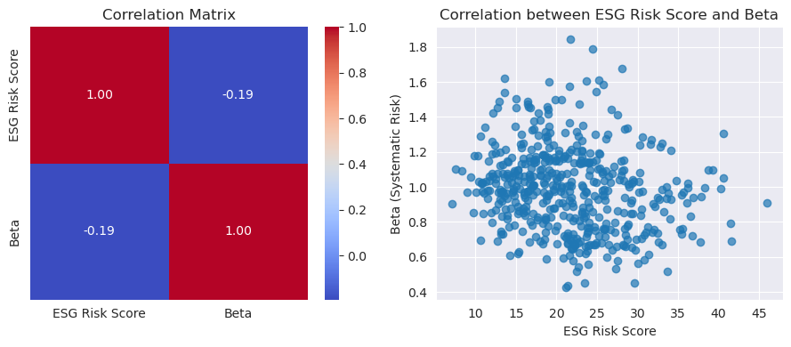

```python
# Correlation between Beta and the corresponding ESG risk score
esg_beta_correlation = df[['ESG Risk Score', 'Beta']].corr()

# Plotting the Correlation Matrix
fig, axes = plt.subplots(1, 2, figsize=(9, 4))

sns.heatmap(esg_beta_correlation, annot=True, cmap='coolwarm', fmt=".2f", ax=axes[0])
axes[0].set_title('Correlation Matrix')

# Plotting the scatter plot to visualize the correlation
axes[1].scatter(df['ESG Risk Score'], df['Beta'], alpha=0.7)
axes[1].set_title('Correlation between ESG Risk Score and Beta')
axes[1].set_xlabel('ESG Risk Score')
axes[1].set_ylabel('Beta (Systematic Risk)')
axes[1].grid(True)

plt.tight_layout()
plt.show()
```

The correlation between Beta and ESG Risk Score is -0.19. A negative correlation suggests that as Beta increases, the ESG Risk Score decreases slightly. However, the strength of this tendency is weak. Notably, though, there are other factors that affect ROE and ESG Risk Score. Therefore, endogenous factors like market capitalization and debt-to-equity ratio also influence beta.

Now, we will attempt to perform a multiple linear regression, attempting to determine which factors affect the ROE of a company and how much ESG Risk Score also impacts that value.

```python
# Removing rows with NaN values in ROE and ESG Risk Score columns
df_filtered = df.dropna(subset=["ROE", "ESG Risk Score", "Revenue", "Debt to Market Cap Ratio", "Profit Margin"])

# Adding a constant term for the regression model
X = sm.add_constant(df_filtered[["ESG Risk Score", "Revenue", "Debt to Market Cap Ratio", "Profit Margin"]])
y = df_filtered["ROE"]

# Linear regression
model = sm.OLS(y, X).fit()

# Extracting coefficients
alpha = model.params[0]
beta_ESG = model.params[1]
p_value_ESG = model.pvalues[1]


# Printing the data
print("Alpha (Intercept):", alpha)
print("Beta (Coefficient for ESG Risk Score):", beta_ESG)
print("P Value (ESG Risk Score):", p_value_ESG)

print("\nRegression Summary:")
print(model.summary())
```

```
Alpha (Intercept): 34.759891947796724
Beta (Coefficient for ESG Risk Score): -0.7972481261101431
P Value (ESG Risk Score): 0.05912281036043718

Regression Summary:
                            OLS Regression Results
==============================================================================
Dep. Variable:                    ROE   R-squared:                       0.063
Model:                            OLS   Adj. R-squared:                  0.055
Method:                 Least Squares   F-statistic:                     7.620
Date:                Mon, 18 Dec 2023   Prob (F-statistic):           6.01e-06
Time:                        09:39:09   Log-Likelihood:                -2522.5
No. Observations:                 457   AIC:                             5055.
Df Residuals:                     452   BIC:                             5076.
Df Model:                           4
Covariance Type:            nonrobust
============================================================================================
                               coef    std err          t      P>|t|      [0.025      0.975]
--------------------------------------------------------------------------------------------
const                       34.7599      9.665      3.596      0.000      15.765      53.755
ESG Risk Score              -0.7972      0.421     -1.892      0.059      -1.625       0.031
Revenue                      0.0002    4.7e-05      4.083      0.000    9.95e-05       0.000
Debt to Market Cap Ratio    -8.5732      3.995     -2.146      0.032     -16.424      -0.722
Profit Margin                0.4594      0.162      2.834      0.005       0.141       0.778
==============================================================================
Omnibus:                      905.121   Durbin-Watson:                   2.007
Prob(Omnibus):                  0.000   Jarque-Bera (JB):          1060875.252
Skew:                          13.493   Prob(JB):                         0.00
Kurtosis:                     237.489   Cond. No.                     2.35e+05
==============================================================================

Notes:
[1] Standard Errors assume that the covariance matrix of the errors is correctly specified.
[2] The condition number is large, 2.35e+05. This might indicate that there are
strong multicollinearity or other numerical problems.
```

We aimed to explore the influence of a company's ESG Risk Score on its ROE anticipating a negative correlation between these two factors, based on recent academic research.

Recognizing that ROE isn't solely influenced by the ESG Risk Score, we incorporated additional independent variables like Revenue, Debt to Market Cap Ratio, and Profit Margin. These factors were chosen because they typically impact ROE.

Upon analyzing the model, we did observe the anticipated negative relationship. However, the statistical significance, as indicated by the p-value, fell slightly short of the established benchmark of 0.05. This suggests that while there's an apparent connection between ESG Risk Score and ROE in our sample, it doesn't reach statistical significance. Notably, the proximity of the p-value to the benchmark indicates that with a larger and more diverse dataset beyond the top 503 companies, a statistically significant relationship might emerge.

#### Index-wide ESG Ratings Analysis

Next, we'll examine the ESG ratings. For this analysis, we'll classify AAA, AA, and A as High ESG Ratings, while considering the remaining ratings as Low ESG Ratings. This comparison will focus on Market Capitalization, Revenue, and ROE.

```python
# All the A ratings will be defined as high ESG ratings, and the rest will be low ESG ratings
high_esg_ratings = ['AAA', 'AA', 'A']
low_esg_ratings = ['BBB','BB', 'B', 'CCC']

# Create a function to categorize ESG ratings
def categorize_esg_rating(rating):
    if rating in high_esg_ratings:
        return 'High ESG Ratings'
    elif rating in low_esg_ratings:
        return 'Low ESG Ratings'

# Apply the categorize_esg_rating function to create the ESG_Category column
df['ESG_Rating_Category'] = df['ESG Rating'].apply(categorize_esg_rating)

# Calculating average Market Cap, Revenue, and ROE for each ESG category
average_metrics = df.groupby('ESG_Rating_Category')[['Market Cap', 'Revenue', 'ROE']].mean()

# Function to format Market Cap
def format_market_cap(market_cap):
    if market_cap >= 1e9:
        return f"{market_cap / 1e9:.0f} billion"
    elif market_cap >= 1e6:
        return f"{market_cap / 1e6:.0f} million"
    else:
        return f"{market_cap:.0f}"

# Function to format Revenue
def format_revenue(revenue):
    if revenue >= 1e3:
        return f"{revenue / 1e3:.2f} thousand"
    elif revenue >= 1e6:
        return f"{revenue / 1e6:.2f} million"
    else:
        return f"{revenue:.0f}"

# Apply the format_market_cap function to the Market Cap column in the average_metrics DataFrame
average_metrics['Market Cap'] = average_metrics['Market Cap'].apply(format_market_cap)
average_metrics['Revenue'] = average_metrics['Revenue'].apply(format_revenue)

average_metrics
```

| ESG_Rating_Category | Market Cap | Revenue | ROE |
| --- | --- | --- | --- |
| High ESG Ratings | 72 billion | 29.90 thousand | 28.461221 |
| Low ESG Ratings | 124 billion | 40.63 thousand | 18.047422 |

Let's look at a visualization for easier understanding.

[figure not shown]

```python
# Create subplots with 1 row and 3 columns
fig, axes = plt.subplots(1, 3, figsize=(15, 5))

# Define colors for low and high ESG
colors = ['#4abb24', '#ff0000']

# Plot the first bar graph for Market Cap
market_cap_values = average_metrics['Market Cap'].str.replace('[^\d.]', '', regex=True).astype(float)
market_cap_colors = [colors[1] if category == 'Low ESG Ratings' else colors[0] for category in average_metrics.index]
axes[0].bar(average_metrics.index, market_cap_values, color=market_cap_colors)
axes[0].set_title('Average Market Cap')
axes[0].set_ylabel('Market Cap (Billions USD)')

# Plot the second bar graph for Revenue
revenue_values = average_metrics['Revenue'].str.replace('[^\d.]', '', regex=True).astype(float)
revenue_colors = [colors[1] if category == 'Low ESG Ratings' else colors[0] for category in average_metrics.index]
axes[1].bar(average_metrics.index, revenue_values, color=revenue_colors)
axes[1].set_title('Average Revenue')
axes[1].set_ylabel('Revenue (Millions USD)')

# Plot the third bar graph for ROE
roe_colors = [colors[1] if category == 'Low ESG Ratings' else colors[0] for category in average_metrics.index]
axes[2].bar(average_metrics.index, average_metrics['ROE'], color=roe_colors)
axes[2].set_title('Average ROE')
axes[2].set_ylabel('ROE (%)')

# Adjust layout for readability
plt.tight_layout()

# Show the plots
plt.show()
```

This analysis implies that there are discernible differences in financial metrics based on the categorization of companies into High and Low ESG Ratings:

Revenue: Similarly, companies classified as having Low ESG Ratings exhibit higher Revenue, on average. This indicates that these companies might generate more income or have larger top-line revenues compared to those with High ESG Ratings. However, despite higher revenue, they might have a lower Return On Equity, indicating potentially less efficient utilization of capital.

ROE: On the contrary, companies categorized as having High ESG Ratings show, on average, a higher ROE. This suggests that these companies, which emphasize or excel in environmental, social, and governance practices, tend to yield better returns concerning their equity investments. Higher ROE typically indicates better profitability and efficient utilization of shareholders' investments.

These observations hint at potential disparities in financial performance between companies with differing ESG Ratings. While companies with High ESG Ratings tend to have better ROE, those with Low ESG Ratings might excel in generating higher revenues but might not translate that revenue into higher returns for their investors, as reflected by their lower ROE.

#### Index-wide ESG Disclosure Score Analysis

As revealed in the Data Cleaning section (Appendix A), it came to our attention that 235 companies opted not to disclose their ESG scores. The specific motivations behind these companies' decisions to withhold their scores are unknown. However, we have chosen to work with the data at hand. It's important to acknowledge that this dataset may not provide a comprehensive representation of all S&P 500 companies due to this lack of disclosure. This limitation is a factor to consider when interpreting the results of our analysis.

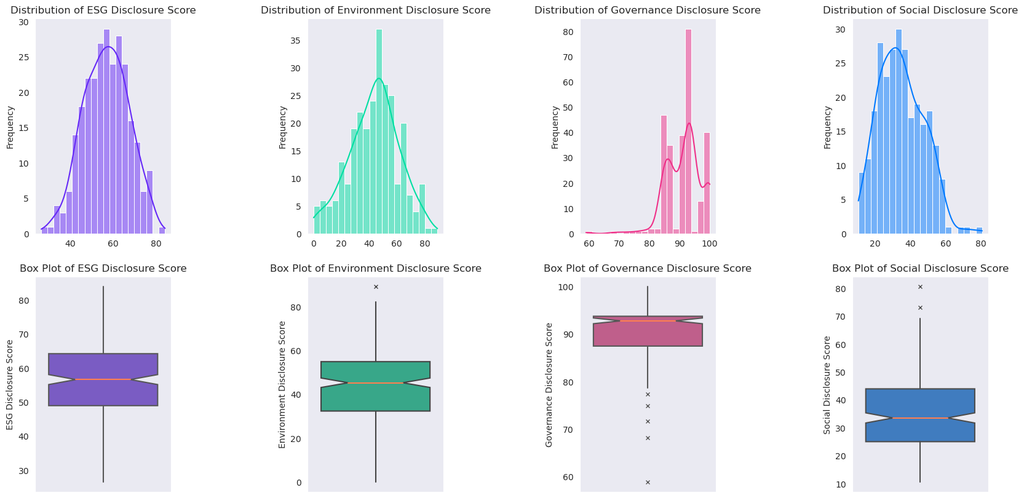

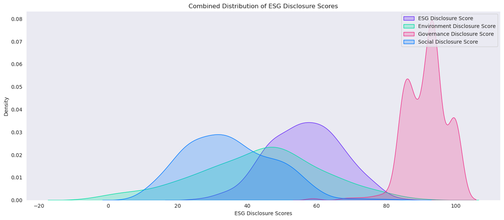

```
Summary Statistics for ESG Disclosure Scores:
╒═══════╤════════════════════════╤════════════════════════════════╤═══════════════════════════════╤═══════════════════════════╕
│       │   ESG Disclosure Score │   Environment Disclosure Score │   Governance Disclosure Score │   Social Disclosure Score │
╞═══════╪════════════════════════╪════════════════════════════════╪═══════════════════════════════╪═══════════════════════════╡
│ count │               268      │                       268      │                     268       │                  268      │
├───────┼────────────────────────┼────────────────────────────────┼───────────────────────────────┼───────────────────────────┤
│ mean  │                56.6683 │                        43.5475 │                      91.4022  │                   34.9202 │
├───────┼────────────────────────┼────────────────────────────────┼───────────────────────────────┼───────────────────────────┤
│ std   │                10.3736 │                        17.7605 │                       5.91942 │                   12.5902 │
├───────┼────────────────────────┼────────────────────────────────┼───────────────────────────────┼───────────────────────────┤
│ min   │                26.5064 │                         0      │                      58.9103  │                   10.6409 │
├───────┼────────────────────────┼────────────────────────────────┼───────────────────────────────┼───────────────────────────┤
│ 25%   │                48.979  │                        32.3996 │                      87.4774  │                   25.1058 │
├───────┼────────────────────────┼────────────────────────────────┼───────────────────────────────┼───────────────────────────┤
│ 50%   │                56.6442 │                        45.3035 │                      92.7754  │                   33.6004 │
├───────┼────────────────────────┼────────────────────────────────┼───────────────────────────────┼───────────────────────────┤
│ 75%   │                64.2566 │                        54.923  │                      93.7387  │                   44.007  │
├───────┼────────────────────────┼────────────────────────────────┼───────────────────────────────┼───────────────────────────┤
│ max   │                84.0258 │                        89.2178 │                     100       │                   80.653  │
╘═══════╧════════════════════════╧════════════════════════════════╧═══════════════════════════════╧═══════════════════════════╛
Outliers in ESG Disclosure Score:
╒════════════════════════╤════════════════════════════════╤═══════════════════════════════╤═══════════════════════════╕
│ ESG Disclosure Score   │ Environment Disclosure Score   │ Governance Disclosure Score   │ Social Disclosure Score   │
╞════════════════════════╪════════════════════════════════╪═══════════════════════════════╪═══════════════════════════╡
╘════════════════════════╧════════════════════════════════╧═══════════════════════════════╧═══════════════════════════╛
Outliers in Environment Disclosure Score:
╒═════╤════════════════════════╤════════════════════════════════╤═══════════════════════════════╤═══════════════════════════╕
│     │   ESG Disclosure Score │   Environment Disclosure Score │   Governance Disclosure Score │   Social Disclosure Score │
╞═════╪════════════════════════╪════════════════════════════════╪═══════════════════════════════╪═══════════════════════════╡
│ 230 │                77.8996 │                        89.2178 │                       93.7387 │                   50.6651 │
╘═════╧════════════════════════╧════════════════════════════════╧═══════════════════════════════╧═══════════════════════════╛
Outliers in Governance Disclosure Score:
╒═════╤════════════════════════╤════════════════════════════════╤═══════════════════════════════╤═══════════════════════════╕
│     │   ESG Disclosure Score │   Environment Disclosure Score │   Governance Disclosure Score │   Social Disclosure Score │
╞═════╪════════════════════════╪════════════════════════════════╪═══════════════════════════════╪═══════════════════════════╡
```

[output cut: 18 more lines]

```python
# Drop NA values from the selected columns
esg_disclosure_scores = df[['ESG Disclosure Score', 'Environment Disclosure Score', 'Governance Disclosure Score', 'Social Disclosure Score']].dropna()

# Set style
sns.set_style("dark")

# Define a custom color palette
disclosure_colors = ["#6528F7", "#00DFA2", "#EF2F88", "#0079FF"]

# Create subplots for histograms and distribution plots
fig, axes = plt.subplots(nrows=2, ncols=4, figsize=(20, 10))
plt.subplots_adjust(wspace=1)

# Iterate through each ESG score column
for i, col in enumerate(esg_disclosure_scores.columns):
    # Plot histogram
    sns.histplot(
        esg_disclosure_scores[col],
        bins=20,
        kde=True,
        ax=axes[0, i],
        color=disclosure_colors[i]
    )
    axes[0, i].set_xlabel('')
    axes[0, i].set_ylabel('Frequency')
    axes[0, i].set_title(f'Distribution of {col}')

    # Plot box plot with the same color
    sns.boxplot(
        y=esg_disclosure_scores[col],
        ax=axes[1, i],
        color=disclosure_colors[i],
        saturation=0.5,
        notch=True,
        showcaps=False,
        flierprops={"marker": "x"},
        medianprops={"color":"coral"}
    )
    axes[1, i].set_ylabel(col)
    axes[1, i].set_xlabel('')
    axes[1, i].set_title(f'Box Plot of {col}')

# Create a single KDE plot for all ESG scores
plt.figure(figsize=(13.6, 6))

# Iterate through each ESG score column and plot its KDE
for i, col in enumerate(esg_disclosure_scores.columns):
    sns.kdeplot(
        esg_disclosure_scores[col],
        color=disclosure_colors[i],
        label=col,
        fill=True
    )

# Add labels and a title
plt.xlabel('ESG Disclosure Scores')
plt.ylabel('Density')
plt.title('Combined Distribution of ESG Disclosure Scores')

# Add a legend
plt.legend()

plt.tight_layout()
plt.show()


# Identify and display outliers
outliers = {}

for col in esg_disclosure_scores.columns:
    Q1 = esg_disclosure_scores[col].quantile(0.25)
    Q3 = esg_disclosure_scores[col].quantile(0.75)
    IQR = Q3 - Q1
    lower_bound = Q1 - 1.5 * IQR
    upper_bound = Q3 + 1.5 * IQR

    col_outliers = esg_disclosure_scores[(esg_disclosure_scores[col] < lower_bound) | (esg_disclosure_scores[col] > upper_bound)]
    outliers[col] = col_outliers

# Display summary statistics as a table
summary_stats = esg_disclosure_scores.describe()
print("Summary Statistics for ESG Disclosure Scores:")
print(tabulate(summary_stats, headers='keys', tablefmt='fancy_grid'))

# Display outliers as tables
for col, outlier_df in outliers.items():
    print(f"Outliers in {col}:")
    print(tabulate(outlier_df, headers='keys', tablefmt='fancy_grid'))
```

The figure above depicts the frequency of disclosure for each value of ESG disclosure score, for the companies who disclosed their scores. There are four frequency bar graphs representing, the ESG Disclosure Score, Environmental Disclosure Score, Governance Disclosure Socre, and Social Disclosure Score. Below the frequency graphs, four box plots are also included for the same four disclosure scores. At the very bottom of the figure, there is a combined distribution graph showing the overlap of all four disclosure scores.

ESG Disclosure Score: For the companies that disclosed their ESG Disclosure Score, they showed a mean score of around 56 with a standard deviation of around 10. This means that 68% of companies had scores between 46 and 66, and 95% of companies had scores between 36 and 76.

Environment Disclosure Score: The Environmental Disclosure Scores had the closest mean score to the overall ESG Disclosure Scores, with a value of around 43 with a larger standard deviation of around 17. Due to the higher standard deviation, the Environmental Disclosure Scores covered a slightly larger range, as seen in the green line of the Combined Distribution of ESG Disclosure Scores graph, where the peak is slightly lower and the coverage of data is wider.

Outlier Analysis: From outlier analysis, we used a box plot and found if any scores fell outside of the whiskers and labelled them as outliers with X marks as seen in the box plots. The overall ESG Disclosure Scores had no outliers, however, all other Disclosure Scores have outliers. We can see that Governance Disclosure Scores had 5 outliers, which were all below the lower limit. When looking at the overall number of companies that disclosed their ESG Disclosure Scores we can see that the outliers only represent 2% of all the companies which is a small portion. Environment Disclosure Score had one outlier and the Social Disclosure Score had two outliers, which both represent less than 1% of the companies. Due to the small amount of outliers, we can determine that they have very minimal effect on the results we calculated.

### 4.2 Sector-specific Analysis

Grouping companies by industry sector will help us compare company performance within similar businesses. It will offer us insights into sector-specific ESG trends. This approach will allow us for a more focused analysis, considering the unique dynamics and challenges within each industry.

#### Sector-Specific ESG Risk Score Analysis

```python
# Grouping data by Industry Sector
grouped_by_sector = df.groupby('Industry Sector')

# Define the sector colors
sector_colours = {
    'Consumer, Non-cyclical': '#636EFA',
    'Consumer, Cyclical': '#EF553B',
    'Technology': '#00CC96',
    'Communications': '#AB63FA',
    'Financial': '#FFA15A',
    'Utilities': '#1BD3F3',
    'Basic Materials': '#FF6692',
    'Industrial': '#B6E880',
    'Energy': '#FF97FF',
}
```

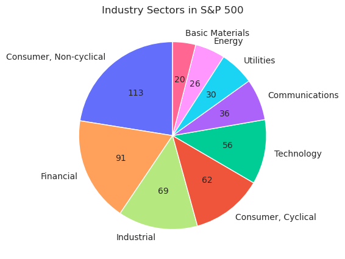

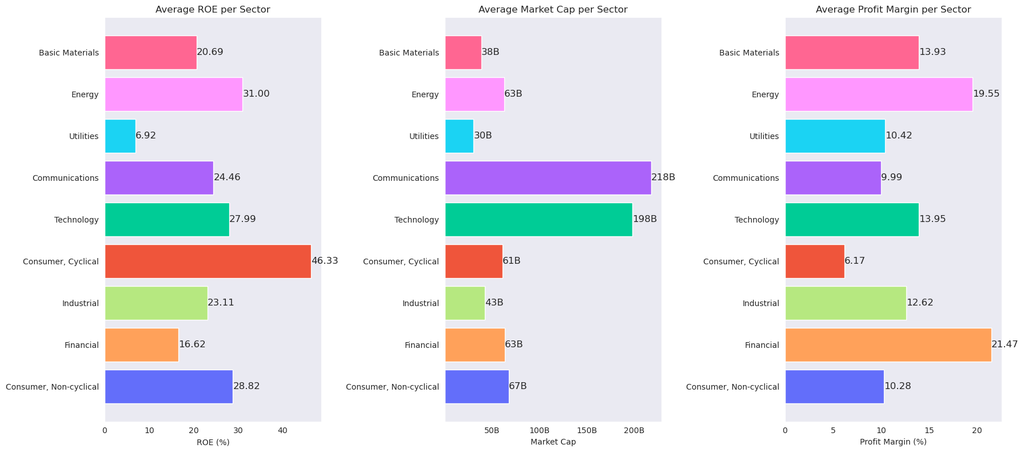

```python
# Count the number of companies in each industry sector
companies_per_sector = grouped_by_sector.size()
companies_per_sector_sorted = companies_per_sector.sort_values(ascending=False)

# Sort the sectors based on the pie chart's ordering
sorted_sectors = companies_per_sector_sorted.index.tolist()

# Generate a consistent color list for the sorted sectors
colors_for_sorted_sectors = [sector_colours[sector] for sector in sorted_sectors]

# Calculate the percentage of companies per sector for the pie chart
sector_percentage = companies_per_sector_sorted / companies_per_sector_sorted.sum()
percentage_values = sector_percentage.tolist()

# Calculate the number of companies per sector for annotation in the pie chart
companies_per_sector = companies_per_sector_sorted.tolist()

fig1, ax1 = plt.subplots(figsize=(12, 5))
patches, texts, autotexts = ax1.pie(percentage_values, labels=sorted_sectors, colors=colors_for_sorted_sectors,
                                    autopct=lambda p: f'{int(round(p * sum(companies_per_sector) / 100))}', startangle=90)
ax1.set_title("Industry Sectors in S&P 500")

# Show the pie chart
plt.show()


# Calculating sector averages for ROE, Market Cap, and Profit Margin
avg_roe = grouped_by_sector['ROE'].mean()
sorted_by_roe = avg_roe.sort_values(ascending=False)
avg_market_cap = grouped_by_sector['Market Cap'].mean()
sorted_by_market_cap = avg_market_cap.sort_values(ascending=False)
avg_profit_margin = grouped_by_sector['Profit Margin'].mean()
sorted_by_profit_margin = avg_profit_margin.sort_values(ascending=False)

# Create the bar charts with annotations
fig2, axes = plt.subplots(1, 3, figsize=(18, 8))

# Function to format Market Cap in the billions
def format_market_cap_billions(value):
    if value >= 1e9:
        return f'{value / 1e9:.0f}B'

# Bar chart for Average ROE per Sector
for i, val in enumerate(sorted_by_roe[sorted_sectors].tolist()):
    axes[0].barh(sorted_sectors[i], val, color=colors_for_sorted_sectors[i])
    axes[0].annotate(f'{val:.2f}', (val, i), va='center', fontsize=12)

axes[0].set_title("Average ROE per Sector")
axes[0].set_xlabel("ROE (%)")

# Bar chart for Average Market Cap per Sector (values in billions)
for i, val in enumerate(sorted_by_market_cap[sorted_sectors].tolist()):
    formatted_val = format_market_cap_billions(val)
    axes[1].barh(sorted_sectors[i], val, color=colors_for_sorted_sectors[i])
    axes[1].annotate(formatted_val, (val, i), va='center', fontsize=12)

axes[1].set_title("Average Market Cap per Sector")
axes[1].set_xlabel("Market Cap")

# Format x-axis for Market Cap
axes[1].xaxis.set_major_locator(mtick.MultipleLocator(base=50e9))
axes[1].xaxis.set_major_formatter(mtick.FuncFormatter(lambda x, pos: format_market_cap_billions(x)))

# Bar chart for Average Profit Margin per Sector
for i, val in enumerate(sorted_by_profit_margin[sorted_sectors].tolist()):
    axes[2].barh(sorted_sectors[i], val, color=colors_for_sorted_sectors[i])
    axes[2].annotate(f'{val:.2f}', (val, i), va='center', fontsize=12)

axes[2].set_title("Average Profit Margin per Sector")
axes[2].set_xlabel("Profit Margin (%)")

# Show the bar charts
plt.tight_layout()
plt.show()
```

The analysis provides an overlook of the composition of the S&P 500 index. Grouping the companies helps us to analyze all the metrics we are interested in among the sectors, and better understand the reasons behind these differences.

The three data we analyzed here are ROE, Market Cap and Profit Margin:

Average ROE: ROE seems to be on average consistent between all different sectors. It is key to take note of the high average ROE in the Consumer, Cyclical sector, which is likely driven by the extremely high ROE of Home Depot which was one of the outliers highlighted earlier. Other key sectors to look at are the Utilities and Financial sectors which comparatively have a low average ROE.

Average Market Cap: The Market Cap seems to be consistent between all the sectors, other than Communications and Technology which both have large average Market Caps. It might be possible to attribute these large average market caps to the sectors that are at the forefront of innovation and technology, leading them to rapid growth and larger Market Caps.

Average Profit Margin: A similar trend can be seen with the Profit Margin, where the average is similar among all sectors. The outlier for Profit Margin is the Consumer, Cyclical sector which has a lower average than the rest.

Similarly, we look at the average ESG Risk Score of each industry.

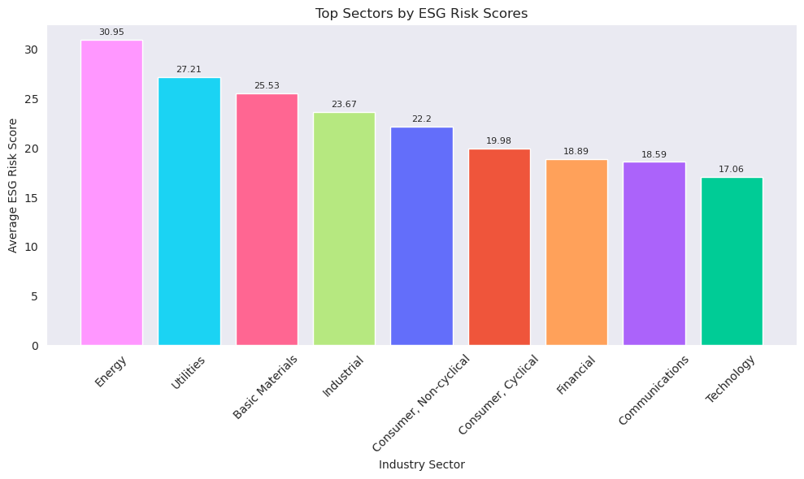

```python
# Calculating average ESG scores for each sector
avg_esg_score = grouped_by_sector['ESG Risk Score'].mean()
sorted_by_esg_score = avg_esg_score.sort_values(ascending=False)

# Filter and match sector colors
sorted_by_esg_score_filtered = sorted_by_esg_score[sorted_by_esg_score.index.isin(sector_colours.keys())]

# Assign colors based on sector
colors = [sector_colours[sector] for sector in sorted_by_esg_score_filtered.index]

# Set up the plot
plt.figure(figsize=(10, 6))

# Create the bar graph with the specified colors and annotate each bar
bars = plt.bar(sorted_by_esg_score_filtered.index, sorted_by_esg_score_filtered, color=colors)

# Adding labels and title
plt.xlabel('Industry Sector')
plt.ylabel('Average ESG Risk Score')
plt.title('Top Sectors by ESG Risk Scores')

# Annotate each bar with its respective ESG risk score
for bar, score in zip(bars, sorted_by_esg_score_filtered):
    plt.text(bar.get_x() + bar.get_width() / 2, bar.get_height() + 0.3, round(score, 2),
             ha='center', va='bottom', fontsize=8)

# Rotating x-axis labels for better readability
plt.xticks(rotation=45)

# Show the plot
plt.tight_layout()
plt.show()
```

We see that the average of the Energy sector is 13 points above the average of the sector with the lowest average ESG risk score: the technology sector. To determine if the energy sector (i.e., the highest) is significantly higher than the technology sector (i.e., the lowest), we test for statistical significance below by calculating the standard error and plotting a coef plot below.

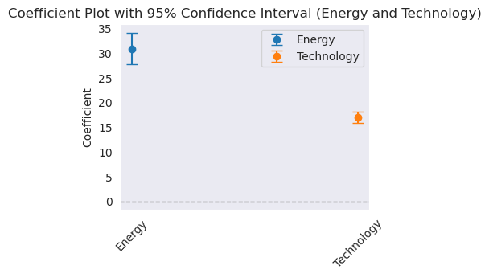

```python
# Filter data for the Energy sector
energy_df = df[df['Industry Sector'] == 'Energy']
X_energy = sm.add_constant(np.ones(len(energy_df)))
y_energy = energy_df['ESG Risk Score']
model_energy = sm.OLS(y_energy, X_energy).fit()

# Filter data for the Technology sector
tech_df = df[df['Industry Sector'] == 'Technology']
X_tech = sm.add_constant(np.ones(len(tech_df)))
y_tech = tech_df['ESG Risk Score']
model_tech = sm.OLS(y_tech, X_tech).fit()

# Plotting the results
plt.figure(figsize=(4,3))

plt.errorbar(['Energy'], [model_energy.params[0]], yerr=model_energy.conf_int(alpha=0.05).iloc[0, 1] - model_energy.params[0],
             fmt='o', capsize=5, label='Energy')

plt.errorbar(['Technology'], [model_tech.params[0]], yerr=model_tech.conf_int(alpha=0.05).iloc[0, 1] - model_tech.params[0],
             fmt='o', capsize=5, label='Technology')

plt.axhline(0, color='gray', linestyle='--', linewidth=1)
plt.title('Coefficient Plot with 95% Confidence Interval (Energy and Technology)')
plt.ylabel('Coefficient')
plt.xticks(rotation=45)
plt.legend()
plt.show()
```

At a 95% confidence level, we can determine that the difference between the average ESG Risk Scores of Energy and Technology is statistically significant. This is depicted in the graph above and can be deduced since the average point of technology falls outside the confidence interval of the Energy ESG Risk Score and vice versa.

#### Sector-specific ESG Rating Analysis

In this section we will focus on determining the number of companies in each sector that fall under each ESG Rating and try to analyze which sectors seem to be better performing overall.

Let's look at the number of companies falling under each sector and ESG rating.

```python
rating_order = ['AAA', 'AA', 'A', 'BBB', 'BB', 'B', 'CCC']

# Map the ESG ratings to a categorical data type with the custom order
df['ESG Rating'] = pd.Categorical(df['ESG Rating'], categories=rating_order, ordered=True)

# Grouping data by 'Industry Sector' and 'ESG Rating' and counting the frequency of each rating within each sector
esg_rating_analysis_columns = ['Industry Sector', 'ESG Rating']
esg_rating_analysis_data = df[esg_rating_analysis_columns].groupby(['Industry Sector', 'ESG Rating']).size().unstack(fill_value=0)

# Re-ordering columns based on the custom order
esg_rating_analysis_data = esg_rating_analysis_data.reindex(columns=rating_order)

# Displaying the analysis of ESG ratings within each sector
print("ESG Rating Analysis by Sector:")
print(esg_rating_analysis_data)
```

```
ESG Rating Analysis by Sector:
ESG Rating              AAA  AA   A  BBB  BB  B  CCC
Industry Sector
Basic Materials           1   8   6    5   0  0    0
Communications            0   7  12    9   6  1    1
Consumer, Cyclical        6  12  18   12   7  1    0
Consumer, Non-cyclical   12  44  32   19   4  0    1
Energy                    2  10  11    3   0  0    0
Financial                 2  22  30   21  11  1    0
Industrial                7  21  27   12   1  0    0
Technology               11  20  15    9   0  0    0
Utilities                 2  12   9    4   1  1    0
```

This table shows the ESG rating breakdown across various industry sectors. Each row represents a specific industry, while columns denote different ESG ratings, ranging from AAA to CCC. From this table we can see that there are no sectors which have all companies lie in the Highest ESG Rating group (None range from AAA to A). Basic Materials, Energy and Technology are all sectors which had ratings ranging from AAA to BBB, these would be considered good results as they fall in the highest intervals of ESG Ratings. The next best performing sector would be Industrial, having ratings ranging from AAA to BB, and this can also be considered as a good performance. Consumer Cyclical, Financial and Utilities follow close behind ranging from ratings of AAA to B. The worst performing sectors are Consumer Non-cyclical and Communications, as they both contain companies which received the rating of CCC. Of the two, Communications has a slightly worse performance as it fails to have any company reach a rating of AAA.

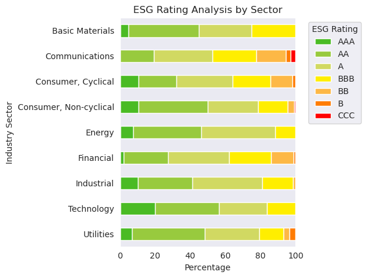

```python
# Calculate percentages for each ESG rating within each sector
total_per_sector = esg_rating_analysis_data.sum(axis=1)
percentages = esg_rating_analysis_data.div(total_per_sector, axis=0) * 100

# Define the colors in the same order as the rating_order
colors = ["#4abb24", "#98ca3e", "#d1d962", "#ffee00", "#fdb846", "#ff7c04", "#ff0000"]

# Plotting the horizontal stacked bar chart with percentages on the x-axis
plt.figure(figsize=(10, 12))

# Stacked bar plot
ax = percentages.plot(kind='barh', stacked=True, color=colors)

plt.xlabel('Percentage')
plt.ylabel('Industry Sector')
plt.title('ESG Rating Analysis by Sector')
plt.gca().invert_yaxis()

# Set x-axis limits from 0 to 100 (for percentages)
ax.set_xlim(0, 100)

# Show the legend with the specified colors and labels
plt.legend(title='ESG Rating', bbox_to_anchor=(1.05, 1), loc='upper left')
plt.tight_layout()

# Display the plot
plt.show()
```

#### Sector-specific Disclosure Scores Analysis

In this section we are analyzing the ESG Disclosure Scores per sector, hoping to shed light on any trends that may appear. However, it is important to remark that Disclosure Scores are optional as seen by the missing 235 Disclosure Scores of the top companies in the S&P50. Additionally, these scores are inconsistently measured between companies causing them to have less credibility than ESG Risk Score and ESG Ratings.

```python
# Calculate the count of companies in each sector
sector_counts = df['Industry Sector'].value_counts()

# Filter to include only companies with missing ESG Disclosure Score
missing_esg_scores = df[df['ESG Disclosure Score'].isnull()]

# Calculate the count of companies in each sector with missing scores
missing_counts = missing_esg_scores['Industry Sector'].value_counts()

# Create a dataframe with the counts
result_table = pd.DataFrame({'Total Companies': sector_counts, 'Companies with Missing Scores': missing_counts})

# Calculate the percentage of companies in each sector that did not disclose scores and round to whole numbers
result_table['Percentage Not Disclosed'] = ((result_table['Companies with Missing Scores'] / result_table['Total Companies']) * 100).round().astype(int)

# Display the final table
print(result_table)
```

```
                        Total Companies  Companies with Missing Scores  \
Basic Materials                      20                             10
Communications                       36                             15
Consumer, Cyclical                   62                             37
Consumer, Non-cyclical              113                             48
Energy                               26                             10
Financial                            91                             37
Industrial                           69                             26
Technology                           56                             33
Utilities                            30                             19

                        Percentage Not Disclosed
Basic Materials                               50
Communications                                42
Consumer, Cyclical                            60
Consumer, Non-cyclical                        42
Energy                                        38
Financial                                     41
Industrial                                    38
Technology                                    59
Utilities                                     63
```

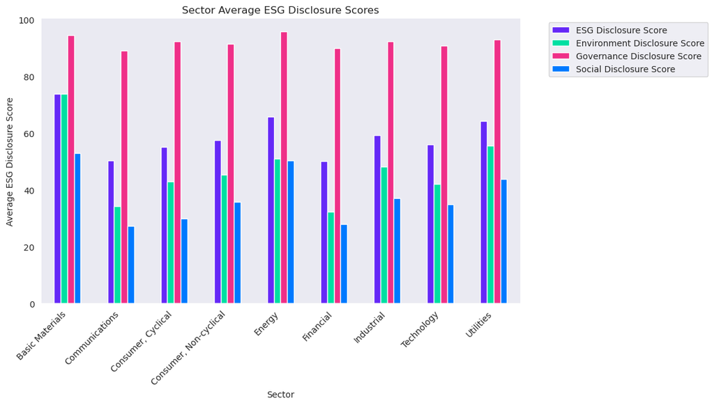

```python
# Drop NA values from the selected columns
disclosure_columns = ['ESG Disclosure Score', 'Environment Disclosure Score', 'Governance Disclosure Score', 'Social Disclosure Score']
esg_disclosure_scores = df[['Industry Sector'] + disclosure_columns].dropna()

# Calculate average ESG scores by sector
sector_avg_esg_scores = esg_disclosure_scores.groupby('Industry Sector')[disclosure_columns].mean()

# Create bar graph
sector_avg_esg_scores.plot(kind='bar', figsize=(10, 6), color=disclosure_colors)
plt.title('Sector Average ESG Disclosure Scores')
plt.ylabel('Average ESG Disclosure Score')
plt.xlabel('Sector')
plt.xticks(rotation=45, ha='right')
plt.legend(labels=disclosure_columns, bbox_to_anchor=(1.05, 1), loc='upper left')
plt.show()
```

From the bar graph above, we can see not much variation in the Governance Disclosure Score (pink bar) between all sectors, meaning it has a marginal impact on the changes in the ESG Disclosure Score. However, when looking at the Environmental Disclosure Scores (green bar) and Social Disclosure Scores (blue bar) we can see a small amount of variation present between sectors, and these variations are reflected in the changes in the overall ESG Disclosure Scores (purple bar).

However, as we stated at the start of this section, this information can be heavily biased by the lack of disclosure and the inconsistent measurement of the metric, so this is more intended towards an additional point of view on the topic that can be further studied provided more data. Additionally, this section attempts to bring light to the importance and future role of ESG Disclosure in the corporate world, expecting that these kinds of parameters will gain a primary role in investor's company selection.

## 5. Discussion and Conclusion

**Index-wide ESG Risk Score Analysis:**

Through looking at the correlation analysis along with the scattering plots of Market Cap, Revenue, ROE and Profit Margin, we attempted to see if the ESG Risk Scores had any effect on the listed company performance metrics. From the signs of the correlation analysis, Market Cap, Revenue and Profit Margin all have a positive correlation with ESG Risk Score, meaning as ESG risk score increases, these metrics also increase. On the other hand, ROE showed a negative correlation, meaning as the ESG Risk score increases, ROE decreases. However, we can see that all the absolute values of all the correlations are less than one. This means that the correlation between these metrics and ESG risk scores was very little, which signifies that the ESG Risk Scores of the companies did not have much to do with the metrics. We also analyzed the correlation between Beta and ESG Risk Score using a correlation matrix. Analogous to ROE, we found a negative correlation with an absolute value of less than one. This leads us to make the same conclusion. We attempted to determine whether the correlation between ROE and ESG Risk Score matched that found in recent academic research using an OLS multiple regression model. We found a negative correlation as expected, however like previous correlation analyses the correlation value was small. Additionally, the OLS regression concluded that we could not say with 95% confidence that the correlation is significant, as the confidence level of the regression was larger than the required benchmark value. From all these different correlations it is difficult to find any strong meaningful relationship between ESG Risk Score and the company performance metrics.

**Index-wide ESG Ratings Analysis:**

After looking at the ESG Risk Scores, we attempted to analyze any patterns found between ESG Ratings and the company performance metrics. We split the ESG Ratings into two groups, all the A ratings were in the High ESG Ratings group, and all the other ratings were in the Low ESG Ratings group. We found the averages for different metrics for the two rating groups and compared the levels to see if any clear trends could be identified. We found that both the average Market Cap and Revenue had higher averages in the Low ESG Ratings group. On the other hand, ROE had higher averages in the High ESG Ratings group. Unfortunately, this prevents us from finding any clear patterns as the metrics show different trends and it is hard to determine the direct connection between the company ratings and the different metrics for different companies.

**Sector Specific Analysis:**

Rather than only looking at companies individually, we also thought it would be interesting to look at possible trends across different sectors. Firstly, we compared the metrics ROE, Market Cap, and Profit Margin between all the different sectors. Through this analysis, we did not see any clear trends for any of the different metrics measured. There were certain sectors which had higher values, but these trends were not consistent for all the different performance metrics, and therefore were inconclusive. We also decided to compare the average ESG Risk Scores for each sector. We took a deeper look at the difference between the sector with the highest average ESG Risk Score, Energy, and the section with the lowest, Technology. When comparing the two sectors, we found with 95% confidence that the difference between the two averages was statistically significant.

**Conclusion:**

With the available data and analyses performed, it is hard to determine the direct effects of ESG metrics on company performance. Despite the many different analyses performed regarding the provided ESG metrics and company performance metrics, we were unable to find any clear trends. It is important to note that our analysis was only looking at the 503 highest revenue companies in the United States which means that the conclusions drawn from this report are not a representation of all companies in the world. To further our understanding of the subject matter, we would need to do a further analysis given more specific information. Other data that can be analyzed would be time data comparing different years and how scores and metrics change over time, as well as data from around the world to provide a more global perspective. Having more knowledge on the impact of ESG metrics on company performance would shed more light on a method to predict future patterns of company performance based on ESG metrics and can allow for higher returns on company investments for investors. Additionally, a better understanding of ESG metrics will allow for a better understanding of a company’s resilience and societal impact. This would allow for a more simplified approach to comprehending the state of the economy and measure the company’s social values when approaching different issues such as climate change, human rights, or equality. A stronger grasp of such concepts would help urge companies to tackle these prevalent issues and help push everyone toward a better future.

## 6. References

Bloomberg. “Bloomberg Terminal.” Bloomberg.com, 2023. https://www.bloomberg.com/professional/solution/bloomberg-terminal/.

MSCI. “ESG Investing: ESG Ratings.” MSCI, 2023. https://www.msci.com/our-solutions/esg-investing/esg-ratings.

Sustainalytics. “ESG Risk Ratings.” sustainalytics.com, 2023. https://www.sustainalytics.com/esg-data.

World Economic Forum. “ESG Is Missing a Metric: R for Resilience.” World Economic Forum, July 2021. https://www.weforum.org/agenda/2021/06/esg-resilience-investment-environment-social-governance/.

## 7. Appendices

- Appendix A: Data Cleaning (Located in separate file).
- Appendix B: ESG Risk Market Cap graph (Located in separate file).
- Appendix C: ESG Risk Score graph (Located in separate file).
- Appendix D: ESG Comparisons graph (Located in separate file).